# Initial Selection Analysis Descriptives

May 15, 2017

# Overview of the Sample

The population sample contains 18,011 distinct corporations with 300,731 players from 194 countries specified countries who speak (as noted in the game) 24 languages.

# How the Population Sample was Generated

For scope and processing, this analysis limits the total population of corporations from which it analyzes. Relevant corporations were identified along the following conditions.

1. **Contains 5+ Players**. This decision rule dictates that thecorporation must contain more than five unique individuals to be considered in the sample. A rare but not entirely uncommon feature of EVE is that one player will control multiple avatars, which are all member to the same corporation. This eases the distribution of resources between the different avatars. These types of corporations are dropped as they do not reflect the coordination dynamics central to this analysis. “Unique Individuals” were flagged using the players email address as a unique identifier. The main data analytics personnel at CCP underscored this method of identifyign all unique players.[^1]
2. **All Dust Characters Dropped**. Dust characters emerged out of a different game engine from the rest of EVE. In Dust, characters played not through ships but through human avatars. The game model resembled a standard first person future but with a twist: EVE and Dust spoke to each other. Thus, EVE players could coordinate planetary attacks that would occur in real time in Dust. The Dust venture ultimately folded, but residuals of these character IDs and corporations still exist in the data, especially as one moves back in time. The assumption is that the data generating process that underpins Dust coordination differs in imporant ways from the behavior being recovered in this analysis from players solely conducting themselves in EVE online. For this reason, all Dust corporation and corporations containing Dust character IDs are removed from the data.
3. **Corporation Creation Date after Jan. 1, 2015**. Understanding group recruitment and selection, expansion, and coordination requires a complete time series of the coorporation from start to the present. This requires that one has the start date contained within the time series of all coorporations in the sample. I arbitrarily set this threshold for 1.1.2015. Thus, the sample excludes all corporations in operation prior to this point.

Given the start date of this project (April 2017), the relevant time period spans from 2015 to mid-April 2017.

In generating the relevant population frame, key features of the corporation were retained. These feature includes:

- the **founder**: the player who started the corporation.
- **all corporation employees** across the relevant time period (and their hire date).
- **Demographic informatio**n about the employee and the founder (such as self-reported DOB, nationality, and language)
- **aggregate information** about the corporation’s behavior. This includes information regarding the number of distinct (i.e. human) players in the corporation (e.g. there could potentially be $N$ number of characters in the corp but only $M$ number of players, where $N > M$. For the following analysis, I care about how actual human are coordinating and interacting together in the environment, not just the number of avatars), the jump patterns of the corporation (i.e. does the corporation travel most in High Sec, Low Sec, Wormhole, or Null Sec space. Each security zone constrains players in different ways and makes demands on players in distinct ways.), and the average number of monthly jumps (which seeks to offer a rough metrec re: how active a corporation is).

From this “population” sample, subsamples will be drawn and analyzed. That said, it’s important to understand general properties of the population sample to highlight its properties.

# Sample Population Descriptives

### Top Twenty Most Populated Corporations

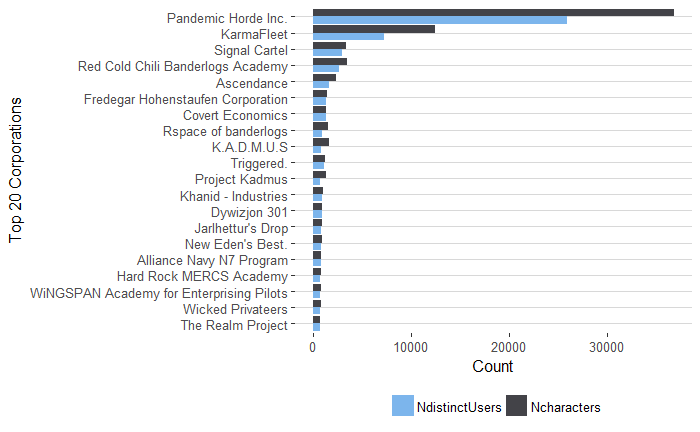

Though only a subset of the top 20 corporations by membership numbers, one can quickly identify two important features. First, “mega” corporations with 1,000 plus members is rare, and second, that there are often more characters than distinct users in these mega corps but that this property diminishes as the corporations shrink in size.

Specifically, *Pandemic Horde* is a distinct outlier in terms of membership and behavior. This corporation is bent on watching the world burn, so to speak. Individuals join knowing that the goal is raiding and combat initiation. The corporation recruits indiscriminantly, and sees itself as a training hub for newer players looking to make the transition into low and null sec activity.

## Geographical Distribution of Players

Below I map the countries of origin of players in the population sample. These geographic information are derived from both self-reported geographic location information, which is then can be corroborated by the user’s IP address. Though not perfect, these geographic measures offer a general sense of the distribution of players from which the analytical samples are drawn. The blue countries denote locations from which a player comes from.

```
Ignoring unknown aesthetics: x, y
```

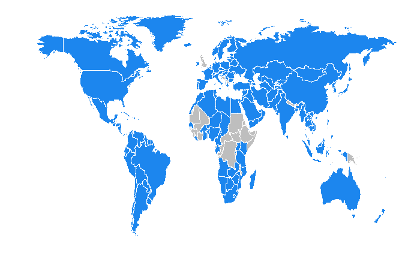

# Corporation as a Unit

The primary unit of analysis is a **member in a corporation** but much of the metrics for this iteraction are generated on the corporation level (such as network density, which measures the interactions between members). The are primary concerns surrounds how unique players in a corporation coordinate and cooperate when playing the game. Corporations in EVE are self-contained units in that the group boundary is clearly delineated within the game. This saves one from needing to “discover” groupings within the interaction patterns between all players (i.e. via a community detection algorithm). Thus, this analysis seeks to exploit the interactions within these corporations to measure the relationship between the selectivity of the group with respect to new members and the underlyign cohesion within the group.

## Membership Flows

Corporation membership is dynamic: some corporations hold onto members for a long time whereas others shed and gain members regularly. When examining group network behavior within corporations, the concept of a membership “flow”" is useful.

Members come and members go, sometimes in large numbers. Observing the flow of participants in and out of a corporation helps approximate membership stresses that might explain some of the variation in cohesion patterns. In addition, indicators such as the likelihood of exiting the group provide valuable information on retention.

To demonstrate these flows, I present a time series plot of 6 corporations randomly selected from the population sample. What is important to note is the fluctuations within membership levels as new members are add and exit. The point is that the potential forms of interaction that one can plausibly observe vary given the number of members. Thus, talking about membership, cohesion, and selection in inevitably a time series problem (one in which I ignore in this initial analysis).

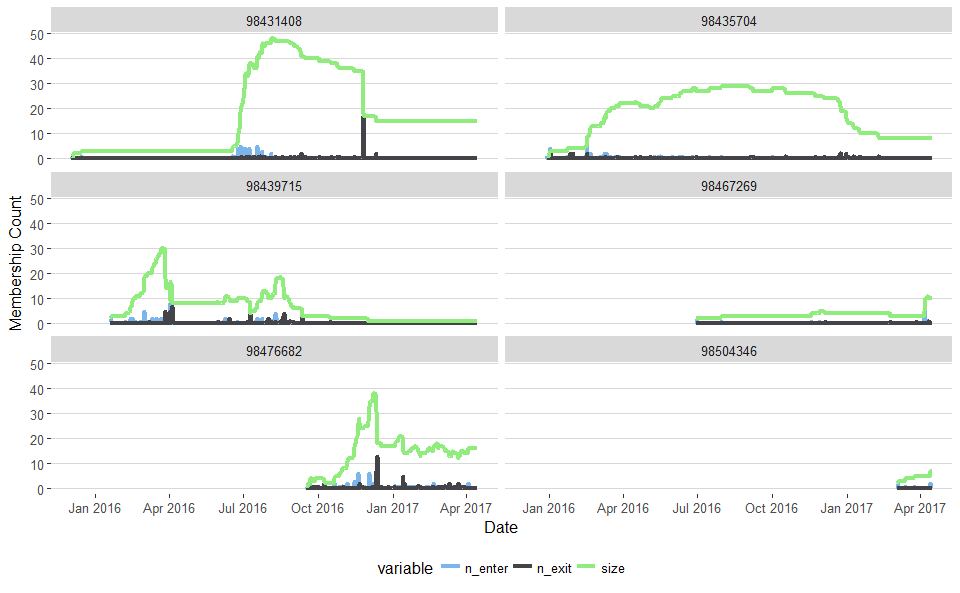

# Analysis

The following analysis is conducted on a simple random sample of 500 corporations from the population sample. The reason behind using a random sample rather than the whole population was primarily motivated by the need for more theory development. Through sampling, one can avoid data fitting to a limited, non-repeatable data source. Sampling also offers the flexibility in terms of computational processing.

## Measuring Selection

First, it is key to understand what the recruitment process is in EVE Online and how it play out? Recruitment in EVE mirrors that of real world firms in that potential employees apply or are invited into a corporation. When applying, applicants are often vetted through a request for an API key. CCP, the company that created EVE, has created an easy way for players to share information about one another through an API that characters themselves can generate. Access to this API record is limited and noisy; thus, information regarding the degree to which this process plays out is limited.

Once vetted, members are accepted for membership. Now, it’s key to note that this process plays out differently within different corporations (which is the main thrust of this investigation). Some corporations in the sample appear to offer only a limited number of individuals who apply into their ranks, whereas other groups appear to be open doors. I argue that through understanding these process we can understand a key feature of how groups develop and decay.

In this analysis, selection is measured first by extracting data from the game’s corporate application logs. These logs contain information regarding which characters were invited, and which characters applied to a corporation, offering a time series of the in-game application process.

In broad stroaks, information on who applied and who was invited could be roughly used to approximate supply and demand. Corporations with a large number of applications could be thought of as “in demand” and rich in a supply of labor whereas a corporation with a large number of invitations could be thought of as in higher demand of labor.

For now, a single variant of the application records are used to offer a rough proxy for group selectivity. By matching the application records to the membership flow data, it’s possible to back out who applied and who was actually accepted from a corporation. One can then leverage the information about the proportion of members who applied and were not accepted over the total number of players who applied to generate metrics on the groups selectivity, where values closer to 0 means that more of those who applied to join the group were let in and values closer to 1 denotes the opposite. Though imperfect, given some of the difficulty with these logs (which I outline in greater detail below), this offers a first cut at the selection processes within groups.

## Measuring Cohesion

Group cohesion is measured by looking at the coordination between players. Player coordination, however, is a computationally taxing concept to recover from the data. First, one needs to know when players are in the same space and time to make a plausible assessment about coordination, but even then there are serious limitations. For example, one might ride the same bus to work each day with the same people (i.e. is in the same time and space as another) but share no real connection with them.

To get around the spatiotemporal limitations of backing out coordination networks, I use a unique log that records when players “warp to” another players. In the game, this process plays out as follows. Two players are going to do something together like mine an astroid or attack another player. To meet up, one player locks onto another and “warps to” them. This behavior consistently follows from coordination and offers a useful proxy for player interactions that are underpinned by cooperative behavior. Thus, each “warp to” is given a tie, and the links between players can be thought of as dynamic network of who is working with who.

As a rough (and admittedly naive) measure of cohesion, I look at the daily **network density**. Network density is measured by first considering all players and their potential connections, which is to say: of all the players in the corporation online today, if they were all coordinating, they would all have ties. Thus, we assess this counter factual world by comparing it to the observed world where, say, only some players interacted. The network density measure is then generated by taking the actual ties and dividing it by the potential ties. Thus, values closer to 0 denote little to no coordination and values closer to 1 denote higher levels of coordination between players.

I use the concept of coordination as a proxy for group cohesion as it offers a viable way of understanding how players spend time and work together. A serious limitation of this measure, of course, is that it will be dramatically smaller in groups with larger populations. Thus, in a group such as the pandemic horde, the network density measure is often approaching 0 even when a fair number of players are working together.

## Initial Findings

The following table presents two forms of initial findings. First, I aggregate all measure to the corporation level, and then I disaggregate down to the month.

**Descriptive Statistics Aggregated by Corporation**

| Statistic | N | Mean | St. Dev. | Min | Max |
| --- | --- | --- | --- | --- | --- |
| aveDens | 495 | 0.034 | 0.058 | 0.000 | 0.521 |
| selective | 495 | 0.141 | 0.174 | 0.000 | 1.000 |
| ave_size | 495 | 45.280 | 304.523 | -23.848 | 6,662.501 |
| ave_exit | 495 | 0.290 | 1.367 | 0.000 | 29.149 |

**Selection on Network Density (by Corporation)**

|  | *Dependent variable:* |  |  |  |
| --- | --- | --- | --- | --- |
|  | Network Density |  |  |  |
|  | (1) | (2) | (3) | (4) |
| selective | -0.039*** | -0.027* | -0.038** | -0.027* |
|  | (0.015) | (0.015) | (0.015) | (0.015) |
| log(ave_size + 1) |  | -0.013*** |  | -0.013*** |
|  |  | (0.002) |  | (0.002) |
| ave_exit |  |  | -0.004* | 0.001 |
|  |  |  | (0.002) | (0.002) |
| Constant | 0.039*** | 0.072*** | 0.040*** | 0.073*** |
|  | (0.003) | (0.006) | (0.003) | (0.006) |
| Observations | 495 | 481 | 495 | 481 |
| R<sup>2</sup> | 0.014 | 0.097 | 0.021 | 0.098 |
| Adjusted R<sup>2</sup> | 0.012 | 0.094 | 0.017 | 0.093 |
| Residual Std. Error | 0.058 (df = 493) | 0.054 (df = 478) | 0.057 (df = 492) | 0.054 (df = 477) |
| F Statistic | 6.828*** (df = 1; 493) | 25.814*** (df = 2; 478) | 5.191*** (df = 2; 492) | 17.321*** (df = 3; 477) |
| *Note:* | p<0.1; p<0.05; p<0.01 |  |  |  |

**Descriptive Statistics Aggregated by Corporation-Month**

| Statistic | N | Mean | St. Dev. | Min | Max |
| --- | --- | --- | --- | --- | --- |
| aveDens | 3,597 | 0.025 | 0.058 | 0.000 | 0.768 |
| selective | 3,597 | 0.128 | 0.232 | 0.000 | 1.000 |
| ave_size | 3,597 | 102.743 | 684.270 | 0.000 | 13,001.470 |
| ave_exit | 3,597 | 0.637 | 3.471 | 0.000 | 114.200 |

**Selection on Network Density (by Corporation-Month)**

|  | *Dependent variable:* |  |  |  |
| --- | --- | --- | --- | --- |
|  | Network Density |  |  |  |
|  | (1) | (2) | (3) | (4) |
| selective | -0.022*** | -0.011*** | -0.021*** | -0.011*** |
|  | (0.004) | (0.004) | (0.004) | (0.004) |
| log(ave_size + 1) |  | -0.013*** |  | -0.014*** |
|  |  | (0.001) |  | (0.001) |
| ave_exit |  |  | -0.001*** | 0.001*** |
|  |  |  | (0.0003) | (0.0003) |
| Constant | 0.028*** | 0.071*** | 0.029*** | 0.074*** |
|  | (0.001) | (0.003) | (0.001) | (0.003) |
| Observations | 3,597 | 3,597 | 3,597 | 3,597 |
| R<sup>2</sup> | 0.008 | 0.096 | 0.011 | 0.099 |
| Adjusted R<sup>2</sup> | 0.007 | 0.095 | 0.010 | 0.098 |
| Residual Std. Error | 0.058 (df = 3595) | 0.055 (df = 3594) | 0.058 (df = 3594) | 0.055 (df = 3593) |
| F Statistic | 27.682*** (df = 1; 3595) | 190.275*** (df = 2; 3594) | 19.414*** (df = 2; 3594) | 131.342*** (df = 3; 3593) |
| *Note:* | p<0.1; p<0.05; p<0.01 |  |  |  |

These initial results demonstrate a relationship between how selective a group is and its network density, but it does so in a way that is theoretically opposite to my predictions. Rather than selectivity as a source of greater cohesion, it would appear that the more applications a group ignores, less cohesive it is.

## Issues and Concerns

All in all, the network and selection measure appear to be problematic and merit being measured in a more novel way.

[^1]: Note that CCP also tracks a “UserID” and a “customerID”, both of which offer a type of unique identification. The userID is inconsistent if new accounts are created. Likewise, the customerID leverages the users IP address to differentiate between players; however, these IDs will change if a user consistently switchs his or her IP address (i.e. uses a different computer, or travels and plays in a different country). For these reasons, user email address offers a unique identification method as most players centralized the email in which their EVE updates and information goes. This allows the user email to be uniquely leveraged to identify distinct players.